# ĐỒ ÁN CUỐI KỲ

## *** Mô hình Random Forest:

Thư viện:

```r
#load
data_RF <- read.csv("./healthcare-dataset-stroke-data.csv")
#see structure
str(data_RF)
```

```
## 'data.frame':    5110 obs. of  12 variables:
##  $ id               : int  9046 51676 31112 60182 1665 56669 53882 10434 27419 60491 ...
##  $ gender           : chr  "Male" "Female" "Male" "Female" ...
##  $ age              : num  67 61 80 49 79 81 74 69 59 78 ...
##  $ hypertension     : int  0 0 0 0 1 0 1 0 0 0 ...
##  $ heart_disease    : int  1 0 1 0 0 0 1 0 0 0 ...
##  $ ever_married     : chr  "Yes" "Yes" "Yes" "Yes" ...
##  $ work_type        : chr  "Private" "Self-employed" "Private" "Private" ...
##  $ Residence_type   : chr  "Urban" "Rural" "Rural" "Urban" ...
##  $ avg_glucose_level: num  229 202 106 171 174 ...
##  $ bmi              : chr  "36.6" "N/A" "32.5" "34.4" ...
##  $ smoking_status   : chr  "formerly smoked" "never smoked" "never smoked" "smokes" ...
##  $ stroke           : int  1 1 1 1 1 1 1 1 1 1 ...
```

```r
#kiểm tra giá trị rỗng
paste0("null data0: ", is.null(data_RF))
```

```
## [1] "null data0: FALSE"
```

```r
#Kiểm tra số lượng đột quỵ
paste0("Amount of Strokes: ", sum(data_RF$stroke))
```

```
## [1] "Amount of Strokes: 249"
```

```r
prop.table(table(data_RF$stroke))
```

```
##
##          0          1
## 0.95127202 0.04872798
```

```r
cat("\n Data is a lot unbalanced. Results will not be good if this is not taken it into account (that was confirmed during some tests).
Data will be balanced after train/test split.")
```

```
##
##  Data is a lot unbalanced. Results will not be good if this is not taken it into account (that was confirmed during some tests).
## Data will be balanced after train/test split.
```

```r
#Điều này nhấn mạnh tầm quan trọng của việc xử lý dữ liệu không cân bằng trong quá trình phân tích và mô hình hóa.
```

#CLEAN DATA

```r
table(factor(data_RF$gender))
```

```
##
## Female   Male  Other
##   2994   2115      1
```

```r
cat("\nTable of Strokes (1)")
```

```
##
## Table of Strokes (1)
```

```r
table(data_RF$gender, data_RF$stroke)
```

```
##
##             0    1
##   Female 2853  141
##   Male   2007  108
##   Other     1    0
```

```r
# chuyển đổi biến "gender" thành dạng numeric bằng cách sử dụng một vòng lặp và câu lệnh điều kiện

cat("\nGender to numeric")
```

```
##
## Gender to numeric
```

```r
data_RF$gender <- ifelse(is.na(data_RF$gender), 0.5,
                      ifelse(data_RF$gender == "Male", 1,
                             ifelse(data_RF$gender == "Female", 0, NA)))
data_RF$gender <- as.numeric(data_RF$gender)
print(head(data_RF))
```

```
##      id gender age hypertension heart_disease ever_married     work_type
## 1  9046      1  67            0             1          Yes       Private
## 2 51676      0  61            0             0          Yes Self-employed
## 3 31112      1  80            0             1          Yes       Private
## 4 60182      0  49            0             0          Yes       Private
## 5  1665      0  79            1             0          Yes Self-employed
## 6 56669      1  81            0             0          Yes       Private
##   Residence_type avg_glucose_level  bmi  smoking_status stroke
## 1          Urban            228.69 36.6 formerly smoked      1
## 2          Rural            202.21  N/A    never smoked      1
## 3          Rural            105.92 32.5    never smoked      1
## 4          Urban            171.23 34.4          smokes      1
## 5          Rural            174.12   24    never smoked      1
## 6          Urban            186.21   29 formerly smoked      1
```

```r
table(factor(data_RF$ever_married))
```

```
##
##   No  Yes
## 1757 3353
```

```r
cat("\nTable of Strokes")
```

```
##
## Table of Strokes
```

```r
table(data_RF$ever_married, data_RF$stroke)
```

```
##
##          0    1
##   No  1728   29
##   Yes 3133  220
```

```r
cat("Kết quả cho thấy, đã từng kết hôn thì bị Đột quỵ còn tệ hơn nhiều, có lẽ chỉ vì nó tương ứng với một người lớn tuổi hơn :)\n")
```

```
## Kết quả cho thấy, đã từng kết hôn thì bị Đột quỵ còn tệ hơn nhiều, có lẽ chỉ vì nó tương ứng với một người lớn tuổi hơn :)
```

```r
cat("\nEver_married to binary")
```

```
##
## Ever_married to binary
```

```r
data_RF$ever_married <- ifelse(data_RF$ever_married == "Yes", 1, 0)
```

```r
#work_type is more difficult.... must transform each type to binary... start with children
table(factor(data_RF$work_type))
```

```
##
##      children      Govt_job  Never_worked       Private Self-employed
##           687           657            22          2925           819
```

```r
cat("\nTable of Strokes (1)")
```

```
##
## Table of Strokes (1)
```

```r
table(data_RF$work_type, data_RF$stroke)
```

```
##
##                    0    1
##   children       685    2
##   Govt_job       624   33
##   Never_worked    22    0
##   Private       2776  149
##   Self-employed  754   65
```

```r
cat("\nWork_type to ... Let's separate in children and never worked (which could also be very young people) - make a new variable 'young' to them\n")
```

```
##
## Work_type to ... Let's separate in children and never worked (which could also be very young people) - make a new variable 'young' to them
```

```r
cat("The remaing are separated in new dummy variables, wither work for others or self-employed (which seems more stressful)")
```

```
## The remaing are separated in new dummy variables, wither work for others or self-employed (which seems more stressful)
```

```r
data_RF$work_type <- as.character(data_RF$work_type)
for (i in 1:length(data_RF$id)) {
    if (data_RF$work_type[i] == "children" || data_RF$work_type[i] == "Never_worked" ) {
        data_RF$young[i] <- 1
    }
    else {
        data_RF$young[i] <- 0
    }
}

#data$work_type <- as.character(data$work_type)
for (i in 1:length(data_RF$id)) {
    if (data_RF$work_type[i] == "Govt_job" || data_RF$work_type[i] == "Private Self" ) {
        data_RF$work_others[i] <- 1
    }
    else {
        data_RF$work_others[i] <- 0
    }
}

for (i in 1:length(data_RF$id)) {
    if (data_RF$work_type[i] == "Self-employed" ) {
        data_RF$work_self[i] <- 1
    }
    else {
        data_RF$work_self[i] <- 0
    }
}
print(head(data_RF))
```

```
##      id gender age hypertension heart_disease ever_married     work_type
## 1  9046      1  67            0             1            1       Private
## 2 51676      0  61            0             0            1 Self-employed
## 3 31112      1  80            0             1            1       Private
## 4 60182      0  49            0             0            1       Private
## 5  1665      0  79            1             0            1 Self-employed
## 6 56669      1  81            0             0            1       Private
##   Residence_type avg_glucose_level  bmi  smoking_status stroke young
## 1          Urban            228.69 36.6 formerly smoked      1     0
## 2          Rural            202.21  N/A    never smoked      1     0
## 3          Rural            105.92 32.5    never smoked      1     0
## 4          Urban            171.23 34.4          smokes      1     0
## 5          Rural            174.12   24    never smoked      1     0
## 6          Urban            186.21   29 formerly smoked      1     0
##   work_others work_self
## 1           0         0
## 2           0         1
## 3           0         0
## 4           0         0
## 5           0         1
## 6           0         0
```

```r
table(factor(data_RF$Residence_type))
```

```
##
## Rural Urban
##  2514  2596
```

```r
cat("\nTable of Strokes (1)")
```

```
##
## Table of Strokes (1)
```

```r
table(data_RF$Residence_type, data_RF$stroke)
```

```
##
##            0    1
##   Rural 2400  114
##   Urban 2461  135
```

```r
cat("\nResidence_type to binary")
```

```
##
## Residence_type to binary
```

```r
data_RF$Residence_type <- ifelse(data_RF$Residence_type == "Urban", 1, 0)
```

```r
cat("\nbmi to numeric")
```

```
##
## bmi to numeric
```

```r
data_RF$bmi <- as.numeric(as.character(data_RF$bmi))
cat("\nreplace NA with mean value\n")
```

```
##
## replace NA with mean value
```

```r
data_RF$bmi[is.na(data_RF$bmi)] <- mean(data_RF$bmi, na.rm = TRUE)
summary(data_RF$bmi)
```

```
##    Min. 1st Qu.  Median    Mean 3rd Qu.    Max.
##   10.30   23.80   28.40   28.89   32.80   97.60
```

```r
#tạo bảng tần số (frequency table) đếm số lần xuất hiện của mỗi giá trị trong biến  "smoking_status" trong tập dữ liệu
table(factor(data_RF$smoking_status))
```

```
##
## formerly smoked    never smoked          smokes         Unknown
##             885            1892             789            1544
```

```r
cat("\nTable of Strokes (1)")
```

```
##
## Table of Strokes (1)
```

```r
table(data_RF$smoking_status, data_RF$stroke)
```

```
##
##                      0    1
##   formerly smoked  815   70
##   never smoked    1802   90
##   smokes           747   42
##   Unknown         1497   47
```

```r
cat("\nSmoking_status to ....never unknown what is unkonown... There are several unknown, so what to do?..")
```

```
##
## Smoking_status to ....never unknown what is unkonown... There are several unknown, so what to do?..
```

```r
cat("\nAssume unknown is somewhere between never smoked and formerly smoked... give them 10..")
```

```
##
## Assume unknown is somewhere between never smoked and formerly smoked... give them 10..
```

```r
data_RF$smoking_status <- as.character(data_RF$smoking_status)
#"Unknown", thì giá trị mới được gán là 10.
for (i in 1:length(data_RF$id)) {
    if (data_RF$smoking_status[i] == "Unknown") {
        data_RF$smoking_status[i] <- 10
    }
#never smoked is 0
    else if (data_RF$smoking_status[i] == "never smoked") {
        data_RF$smoking_status[i] <- 0
    }
#formerly smoked is 20
    else if (data_RF$smoking_status[i] == "formerly smoked") {
        data_RF$smoking_status[i] <- 30
    }
#smokes is 30
    else if (data_RF$smoking_status[i] == "smokes") {
        data_RF$smoking_status[i] <- 50
    }
}
data_RF$smoking_status <- as.numeric(data_RF$smoking_status)
```

```r
#confirm changes
length(data_RF$id)
```

```
## [1] 5110
```

```r
for (i in 1:length(data_RF$id)) {
    if (data_RF$stroke[i] >1) {
        print("ngoai le")
    }
}
cat("drop unused columns")
```

```
## drop unused columns
```

```r
data_RF <- data_RF[ -c(1,7) ]
str(data_RF)
```

```
## 'data.frame':    5110 obs. of  13 variables:
##  $ gender           : num  1 0 1 0 0 1 1 0 0 0 ...
##  $ age              : num  67 61 80 49 79 81 74 69 59 78 ...
##  $ hypertension     : int  0 0 0 0 1 0 1 0 0 0 ...
##  $ heart_disease    : int  1 0 1 0 0 0 1 0 0 0 ...
##  $ ever_married     : num  1 1 1 1 1 1 1 0 1 1 ...
##  $ Residence_type   : num  1 0 0 1 0 1 0 1 0 1 ...
##  $ avg_glucose_level: num  229 202 106 171 174 ...
##  $ bmi              : num  36.6 28.9 32.5 34.4 24 ...
##  $ smoking_status   : num  30 0 0 50 0 30 0 0 10 10 ...
##  $ stroke           : int  1 1 1 1 1 1 1 1 1 1 ...
##  $ young            : num  0 0 0 0 0 0 0 0 0 0 ...
##  $ work_others      : num  0 0 0 0 0 0 0 0 0 0 ...
##  $ work_self        : num  0 1 0 0 1 0 0 0 0 0 ...
```

```r
apply(data_RF, 2, function(x) any(is.na(x)))
```

```
##            gender               age      hypertension     heart_disease
##              TRUE             FALSE             FALSE             FALSE
##      ever_married    Residence_type avg_glucose_level               bmi
##             FALSE             FALSE             FALSE             FALSE
##    smoking_status            stroke             young       work_others
##             FALSE             FALSE             FALSE             FALSE
##         work_self
##             FALSE
```

```r
library(corrplot)
cat("check the correlations")
```

```
## check the correlations
```

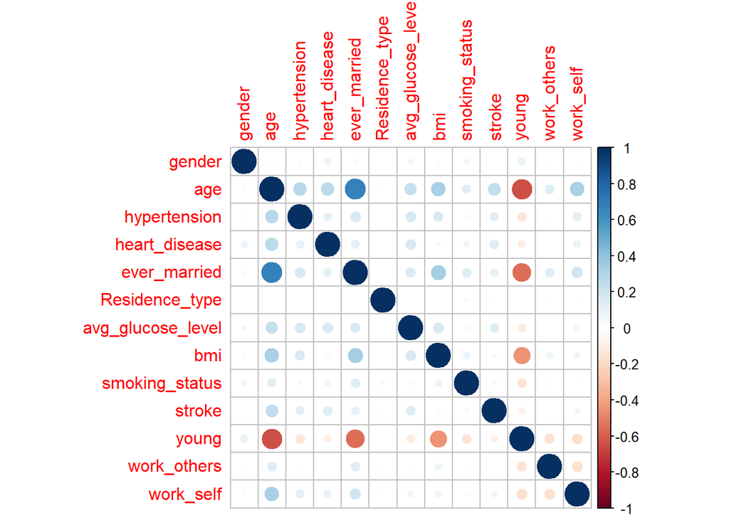

```r
correlations <- cor(data_RF, method = "pearson", use = "pairwise.complete.obs")
corrplot(correlations, method = "circle")
```

```r
cat("Từ biểu đồ tương quan, Young có mối tương quan rõ rệt với các biến khác, và ever married cũng có một mối tương quan tương đối với một số biến khác")
```

```
## Từ biểu đồ tương quan, Young có mối tương quan rõ rệt với các biến khác, và ever married cũng có một mối tương quan tương đối với một số biến khác
```

```r
library(dplyr)
data_RF1 <- data_RF[,c("gender","age","hypertension","heart_disease","Residence_type","avg_glucose_level","bmi","smoking_status","work_others","work_self","stroke")]
#after first run analysis, the focus was decided on this variables
data_RF2 <- data_RF[,c("age","hypertension","avg_glucose_level","work_self","stroke")]

#normalize data (excep stroke)
data_scaled0 <- scale(data_RF2[,c(-5)])
#Đoạn trên thực hiện chuẩn hóa dữ liệu trong biến "data2", trừ cột "stroke". Hàm scale() được sử dụng để chuẩn hóa dữ liệu bằng cách trừ giá trị trung bình và chia cho độ lệch chuẩn của mỗi biến. Cột "stroke" được loại bỏ bằng cách sử dụng [-5].
data_scaled <- cbind(data_scaled0, data_RF$stroke)

data_scaled <- as.data.frame(data_scaled) # chuyển đổi "data_scaled" thành một đối tượng kiểu "data.frame" để dễ dàng xử lý và hiển thị.
data_scaled <- rename(data_scaled,"stroke" =  V5)
print(head(data_scaled))
```

```
##         age hypertension avg_glucose_level  work_self stroke
## 1 1.0513314   -0.3285697       2.706110617 -0.4368378      1
## 2 0.7859932   -0.3285697       2.121350940  2.2887313      1
## 3 1.6262309   -0.3285697      -0.005027809 -0.4368378      1
## 4 0.2553167   -0.3285697       1.437217451 -0.4368378      1
## 5 1.5820079    3.0428986       1.501037522  2.2887313      1
## 6 1.6704540   -0.3285697       1.768021830 -0.4368378      1
```

```r
#Chuẩn bị dữ liệu để thực hiện phân chia tập huấn luyện và tập kiểm tra (train/test split) trong mô hình học máy sử dụng gói caret trong R.
cat("Train Test split - using caret\n")
```

```
## Train Test split - using caret
```

```r
data_RF2$hypertension <- as.factor(data_RF2$hypertension)
data_RF2$work_self <- as.factor(data_RF2$work_self)
data_RF2$stroke <- as.factor(data_RF2$stroke)
```

```r
library(caret)
#sử dụng gói caret trong R để thực hiện phân chia tập(train/test split).
cat("Train Test split - using caret\n")
```

```
## Train Test split - using caret
```

```r
trainIndex2 <- createDataPartition(data_RF2$stroke, p = 0.7, list = FALSE, times = 1)
#Dòng này sử dụng hàm createDataPartition để tạo ra chỉ số (index) cho tập huấn luyện. Hàm này sẽ phân chia dữ liệu dựa trên biến "stroke" trong tập dữ liệu "data2" với tỷ lệ 0.7 (70% train và 30% test).
dataTrain02 <- data_RF2[ trainIndex2,]
dataTest2  <- data_RF2[-trainIndex2,]
head(dataTrain02)
```

```
##   age hypertension avg_glucose_level work_self stroke
## 1  67            0            228.69         0      1
## 2  61            0            202.21         1      1
## 3  80            0            105.92         0      1
## 5  79            1            174.12         1      1
## 7  74            1             70.09         0      1
## 9  59            0             76.15         0      1
```

```r
str(dataTrain02)
```

```
## 'data.frame':    3578 obs. of  5 variables:
##  $ age              : num  67 61 80 79 74 59 81 61 79 75 ...
##  $ hypertension     : Factor w/ 2 levels "0","1": 1 1 1 2 2 1 2 1 1 2 ...
##  $ avg_glucose_level: num  228.7 202.2 105.9 174.1 70.1 ...
##  $ work_self        : Factor w/ 2 levels "0","1": 1 2 1 2 1 1 1 1 1 1 ...
##  $ stroke           : Factor w/ 2 levels "0","1": 2 2 2 2 2 2 2 2 2 2 ...
```

```r
head(dataTest2)
```

```
##    age hypertension avg_glucose_level work_self stroke
## 4   49            0            171.23         0      1
## 6   81            0            186.21         0      1
## 8   69            0             94.39         0      1
## 10  78            0             58.57         0      1
## 13  54            0            104.51         0      1
## 14  78            0            219.84         0      1
```

```r
str(dataTest2)
```

```
## 'data.frame':    1532 obs. of  5 variables:
##  $ age              : num  49 81 69 78 54 78 50 64 60 71 ...
##  $ hypertension     : Factor w/ 2 levels "0","1": 1 1 1 1 1 1 2 1 1 1 ...
##  $ avg_glucose_level: num  171.2 186.2 94.4 58.6 104.5 ...
##  $ work_self        : Factor w/ 2 levels "0","1": 1 1 1 1 1 1 2 1 1 1 ...
##  $ stroke           : Factor w/ 2 levels "0","1": 2 2 2 2 2 2 2 2 2 2 ...
```

```r
#sử dụng gói ROSE trong R để cân bằng dữ liệu tập train bằng cách áp dụng phương pháp oversampling
library(ROSE)
cat("Balance (train) data by oversampling. From 5% to 30%\n")
```

```
## Balance (train) data by oversampling. From 5% to 30%
```

```r
dataTrain2 <- ovun.sample(as.factor(stroke) ~ ., data = dataTrain02, method = 'over', p = 0.3)$data
str(dataTrain2)
```

```
## 'data.frame':    4882 obs. of  5 variables:
##  $ age              : num  3 58 8 70 14 75 32 79 79 37 ...
##  $ hypertension     : Factor w/ 2 levels "0","1": 1 2 1 1 1 1 1 1 1 1 ...
##  $ avg_glucose_level: num  95.1 88 110.9 69 161.3 ...
##  $ work_self        : Factor w/ 2 levels "0","1": 1 1 1 1 1 2 1 1 1 1 ...
##  $ stroke           : Factor w/ 2 levels "0","1": 1 1 1 1 1 1 1 1 1 1 ...
```

```r
#Phương pháp oversampling được xác định bởi method = 'over', và tỷ lệ oversampling là 0.3 (30%) được xác định bởi p = 0.3. Kết quả của hàm là tập dữ liệu đã được cân bằng, được gán cho biến dataTrain2.
```

```r
library(randomForest)
rf <- randomForest(stroke ~., data = dataTrain2, ntree = 1000, mtry = 1)
# xây dựng mô hình Random Forest. ntree = 1000: Trong trường hợp này, mô hình sẽ sử dụng 1000 cây quyết định.
#mtry = 1: Trong trường hợp này, chỉ có 1 biến được chọn ngẫu nhiên để xem xét khi xây dựng mỗi cây quyết định.
```

```r
rf
```

```
##
## Call:
##  randomForest(formula = stroke ~ ., data = dataTrain2, ntree = 1000,      mtry = 1)
##                Type of random forest: classification
##                      Number of trees: 1000
## No. of variables tried at each split: 1
##
##         OOB estimate of  error rate: 17.76%
## Confusion matrix:
##      0   1 class.error
## 0 3087 316  0.09285924
## 1  551 928  0.37254902
```

```r
summary(rf)
```

```
##                 Length Class  Mode
## call               5   -none- call
## type               1   -none- character
## predicted       4882   factor numeric
## err.rate        3000   -none- numeric
## confusion          6   -none- numeric
## votes           9764   matrix numeric
## oob.times       4882   -none- numeric
## classes            2   -none- character
## importance         4   -none- numeric
## importanceSD       0   -none- NULL
## localImportance    0   -none- NULL
## proximity          0   -none- NULL
## ntree              1   -none- numeric
## mtry               1   -none- numeric
## forest            14   -none- list
## y               4882   factor numeric
## test               0   -none- NULL
## inbag              0   -none- NULL
## terms              3   terms  call
```

```r
cat("Predict on Train")
```

```
## Predict on Train
```

```r
predRF_train <- predict(rf)
#how they look
length(predRF_train)
```

```
## [1] 4882
```

```r
head(predRF_train,50)
```

```
##  1  2  3  4  5  6  7  8  9 10 11 12 13 14 15 16 17 18 19 20 21 22 23 24 25 26
##  0  0  0  0  0  0  0  1  0  0  0  0  0  0  0  0  1  0  0  0  0  0  0  0  0  0
## 27 28 29 30 31 32 33 34 35 36 37 38 39 40 41 42 43 44 45 46 47 48 49 50
##  0  0  0  0  0  0  0  1  0  1  0  0  0  1  0  0  0  0  0  0  1  0  0  0
## Levels: 0 1
```

```r
cat("Predict on Test")
```

```
## Predict on Test
```

```r
predRF_test <- predict(rf, newdata = dataTest2)
#how they look
length(predRF_test)
```

```
## [1] 1532
```

```r
head(predRF_test,50)
```

```
##   4   6   8  10  13  14  16  17  19  21  22  23  27  29  33  34  36  39  42  44
##   0   1   0   0   0   1   0   1   0   1   0   0   0   0   1   0   1   0   0   0
##  45  51  55  60  65  70  74  76  78  80  87  94  97  98 100 110 115 116 121 123
##   1   0   1   0   1   1   1   0   1   0   0   1   0   1   0   0   0   1   0   1
## 124 127 134 138 141 142 159 160 161 165
##   0   1   0   1   0   0   0   1   0   1
## Levels: 0 1
```

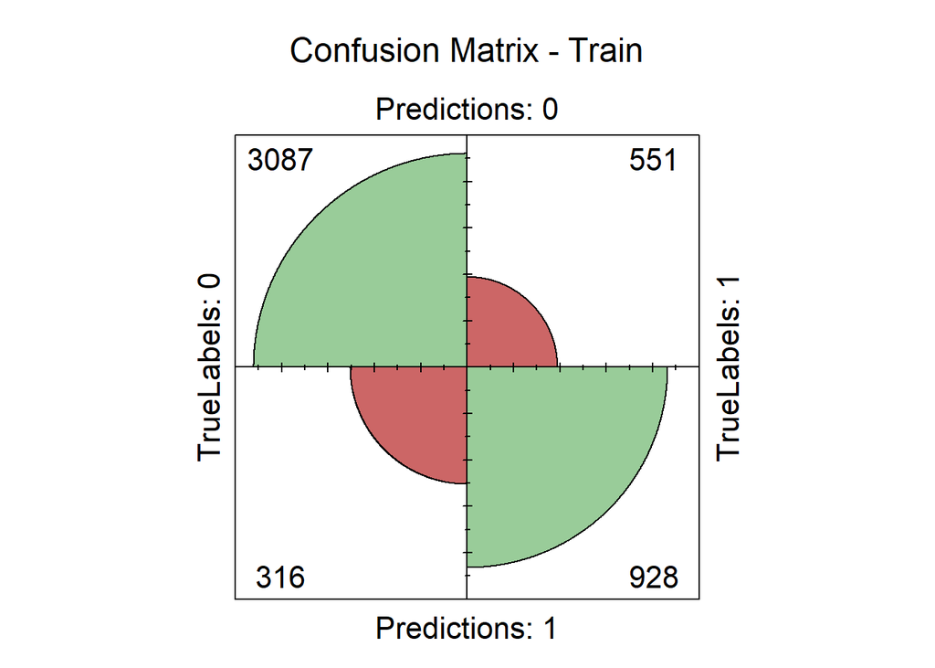

```r
#Confusion Matrix in Train
a2 <- table(Predictions = predRF_train, TrueLabels = dataTrain2$stroke)
fourfoldplot(a2, color = c("#CC6666", "#99CC99"),
             conf.level = 0, margin = 1, main = "Confusion Matrix - Train")
```

```r
set.seed(122)
#Accuracy
acc2 <- ( a2[2,2] + a2[1,1] ) / (length(dataTrain2$stroke))
cat("Accuracy = ",acc2 )
```

```
## Accuracy =  0.8224088
```

```r
#F1
Precision2 =  a2[2,2] / ( a2[2,2] + a2[2,1] )
# in ra màn hình độ chính xác của mô hình dự đoán trên tập train bằng cách sử dụng hàm cat()
cat("\nPrecision = ",Precision2 )
```

```
##
## Precision =  0.7459807
```

```r
#tính toán độ nhạy dự đoán dương tính (recall) của mô hình
Recall2 =  a2[2,2] / ( a2[2,2] + a2[1,2] )
cat("\nRecall = ",Recall2 )
```

```
##
## Recall =  0.627451
```

```r
F1score2  = 2*(Recall2 * Precision2) / (Recall2 + Precision2)
cat("\nF1 score = ",F1score2 )
```

```
##
## F1 score =  0.6816012
```

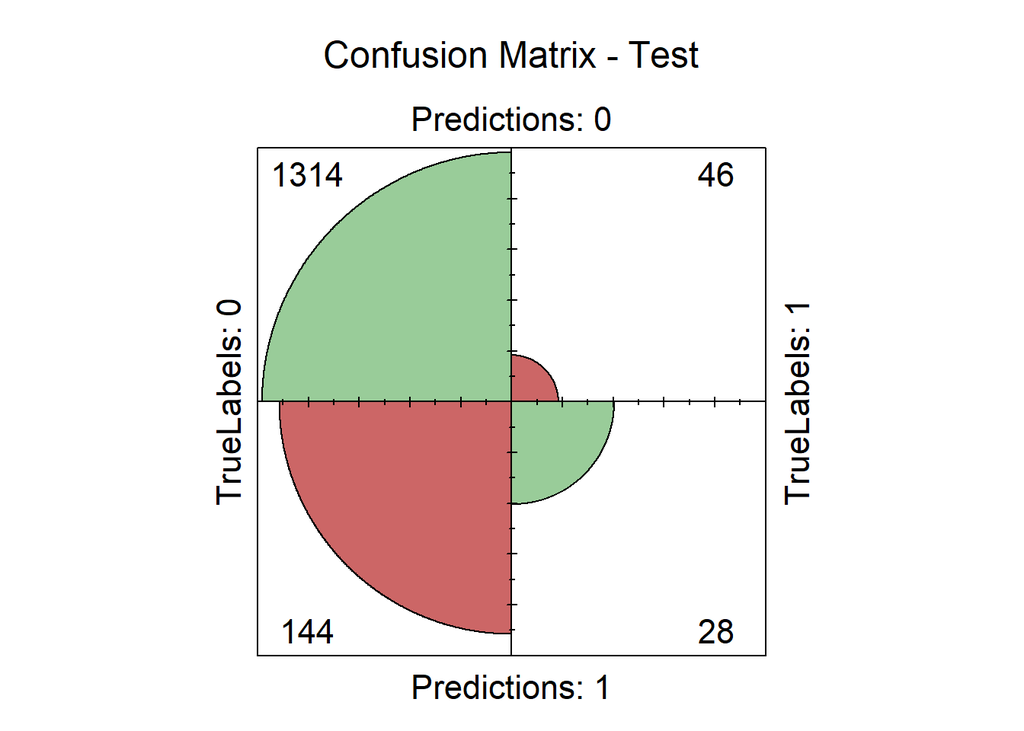

```r
#tính toán và hiển thị ma trận nhầm lẫn Confusion Matrix - TEST
b2 <- table(Predictions = predRF_test, TrueLabels = dataTest2$stroke)
fourfoldplot(b2, color = c("#CC6666", "#99CC99"),
             conf.level = 0, margin = 1, main = "Confusion Matrix - Test")
```

```r
set.seed(122)
#Accuracy
acc2 <- ( b2[2,2] + b2[1,1] ) / (length(dataTest2$stroke))
cat("Accuracy = ",acc2 )
```

```
## Accuracy =  0.8759791
```

```r
#F1
Precision2 =  b2[2,2] / ( b2[2,2] + b2[2,1] )
#in ra màn hình độ chính xác của mô hình dự đoán trên tập TEST bằng cách sử dụng hàm cat(). Chuỗi "Accuracy = " được kết hợp với giá trị của acc2 để hiển thị đầy đủ thông tin.
cat("\nPrecision = ",Precision2 )
```

```
##
## Precision =  0.1627907
```

```r
Recall2 =  b2[2,2] / ( b2[2,2] + b2[1,2] )
cat("\nRecall = ",Recall2 )
```

```
##
## Recall =  0.3783784
```

```r
F1score2  = 2*(Recall2 * Precision2) / (Recall2 + Precision2)
cat("\nF1 score = ",F1score2 )
```

```
##
## F1 score =  0.2276423
```

```r
cat("Dựa trên những kết quả này, mô hình có xu hướng overfitting trên tập dữ liệu huấn luyện, tức là nó hoạt động tốt hơn trên dữ liệu đã được huấn luyện mà không tổng quát hóa tốt cho dữ liệu mới. \n \n ")
```

```
## Dựa trên những kết quả này, mô hình có xu hướng overfitting trên tập dữ liệu huấn luyện, tức là nó hoạt động tốt hơn trên dữ liệu đã được huấn luyện mà không tổng quát hóa tốt cho dữ liệu mới.
##
##
```

```r
 cat("Điều này được thể hiện qua sự khác biệt đáng kể giữa các độ đo hiệu suất trên tập huấn luyện và tập kiểm tra. Để cải thiện hiệu suất của mô hình trên dữ liệu kiểm tra, có thể cân nhắc điều chỉnh tham số hoặc tăng cường dữ liệu huấn luyện để đảm bảo tính tổng quát hóa tốt hơn\n")
```

```
## Điều này được thể hiện qua sự khác biệt đáng kể giữa các độ đo hiệu suất trên tập huấn luyện và tập kiểm tra. Để cải thiện hiệu suất của mô hình trên dữ liệu kiểm tra, có thể cân nhắc điều chỉnh tham số hoặc tăng cường dữ liệu huấn luyện để đảm bảo tính tổng quát hóa tốt hơn
```

## *** Mô hình Decision Tree

Thự viện:

# Dữ liệu được đọc từ tệp CSV và lưu vào biến data

```r
data_DT <- read_csv("./healthcare-dataset-stroke-data.csv")  %>%
  #Cột "hypertension" và "heart_disease" được chuyển đổi từ giá trị số thành giá trị "Yes" và "No" sử dụng hàm recode()
        mutate(hypertension = recode(hypertension, `1` = "Yes", `0` = "No"),
                heart_disease = recode(heart_disease, `1` = "Yes", `0` = "No")) %>%
        mutate_if(is.character, as.factor) %>%
  #Cột "id" được loại bỏ khỏi bảng dữ liệu sử dụng hàm select()
        select(-id)
glimpse(data_DT)
```

```
## Rows: 5,110
## Columns: 11
## $ gender            <fct> Male, Female, Male, Female, Female, Male, Male, Fema…
## $ age               <dbl> 67, 61, 80, 49, 79, 81, 74, 69, 59, 78, 81, 61, 54, …
## $ hypertension      <fct> No, No, No, No, Yes, No, Yes, No, No, No, Yes, No, N…
## $ heart_disease     <fct> Yes, No, Yes, No, No, No, Yes, No, No, No, No, Yes, …
## $ ever_married      <fct> Yes, Yes, Yes, Yes, Yes, Yes, Yes, No, Yes, Yes, Yes…
## $ work_type         <fct> Private, Self-employed, Private, Private, Self-emplo…
## $ Residence_type    <fct> Urban, Rural, Rural, Urban, Rural, Urban, Rural, Urb…
## $ avg_glucose_level <dbl> 228.69, 202.21, 105.92, 171.23, 174.12, 186.21, 70.0…
## $ bmi               <fct> 36.6, N/A, 32.5, 34.4, 24, 29, 27.4, 22.8, N/A, 24.2…
## $ smoking_status    <fct> formerly smoked, never smoked, never smoked, smokes,…
## $ stroke            <dbl> 1, 1, 1, 1, 1, 1, 1, 1, 1, 1, 1, 1, 1, 1, 1, 1, 1, 1…
```

# Tạo một tóm tắt thống kê cho dữ liệu data, loại bỏ cột đầu tiên

```r
skim(data_DT[, -1])
```

Data summary

| Name | data_DT[, -1] |
| --- | --- |
| Number of rows | 5110 |
| Number of columns | 10 |
| _______________________ |  |
| Column type frequency: |  |
| factor | 7 |
| numeric | 3 |
| ________________________ |  |
| Group variables | None |

**Variable type: factor**

| skim_variable | n_missing | complete_rate | ordered | n_unique | top_counts |
| --- | --- | --- | --- | --- | --- |
| hypertension | 0 | 1 | FALSE | 2 | No: 4612, Yes: 498 |
| heart_disease | 0 | 1 | FALSE | 2 | No: 4834, Yes: 276 |
| ever_married | 0 | 1 | FALSE | 2 | Yes: 3353, No: 1757 |
| work_type | 0 | 1 | FALSE | 5 | Pri: 2925, Sel: 819, chi: 687, Gov: 657 |
| Residence_type | 0 | 1 | FALSE | 2 | Urb: 2596, Rur: 2514 |
| bmi | 0 | 1 | FALSE | 419 | N/A: 201, 28.: 41, 28.: 38, 26.: 37 |
| smoking_status | 0 | 1 | FALSE | 4 | nev: 1892, Unk: 1544, for: 885, smo: 789 |

**Variable type: numeric**

| skim_variable | n_missing | complete_rate | mean | sd | p0 | p25 | p50 | p75 | p100 | hist |
| --- | --- | --- | --- | --- | --- | --- | --- | --- | --- | --- |
| age | 0 | 1 | 43.23 | 22.61 | 0.08 | 25.00 | 45.00 | 61.00 | 82.00 | ▅▆▇▇▆ |
| avg_glucose_level | 0 | 1 | 106.15 | 45.28 | 55.12 | 77.24 | 91.88 | 114.09 | 271.74 | ▇▃▁▁▁ |
| stroke | 0 | 1 | 0.05 | 0.22 | 0.00 | 0.00 | 0.00 | 0.00 | 1.00 | ▇▁▁▁▁ |

#loại bỏ các hàng có giá trị thiếu (NA) từ bảng dữ liệu data

```r
data_DT <- na.omit(data_DT)
data_DT
```

```
## # A tibble: 5,110 × 11
##    gender   age hypertension heart_disease ever_married work_type Residence_type
##    <fct>  <dbl> <fct>        <fct>         <fct>        <fct>     <fct>
##  1 Male      67 No           Yes           Yes          Private   Urban
##  2 Female    61 No           No            Yes          Self-emp… Rural
##  3 Male      80 No           Yes           Yes          Private   Rural
##  4 Female    49 No           No            Yes          Private   Urban
##  5 Female    79 Yes          No            Yes          Self-emp… Rural
##  6 Male      81 No           No            Yes          Private   Urban
##  7 Male      74 Yes          Yes           Yes          Private   Rural
##  8 Female    69 No           No            No           Private   Urban
##  9 Female    59 No           No            Yes          Private   Rural
## 10 Female    78 No           No            Yes          Private   Urban
## # ℹ 5,100 more rows
## # ℹ 4 more variables: avg_glucose_level <dbl>, bmi <fct>, smoking_status <fct>,
## #   stroke <dbl>
```

```r
# Kiểm tra cột gender
as.data.frame(table(data_DT$gender))
```

```
##     Var1 Freq
## 1 Female 2994
## 2   Male 2115
## 3  Other    1
```

```r
# Do chỉ có một giá trị 'other' nên tiến hành xoá nó khỏi cột gender để không ảnh hưởng việc phân tích
data_DT = data_DT[!data_DT$gender == 'Other',]
data_DT
```

```
## # A tibble: 5,109 × 11
##    gender   age hypertension heart_disease ever_married work_type Residence_type
##    <fct>  <dbl> <fct>        <fct>         <fct>        <fct>     <fct>
##  1 Male      67 No           Yes           Yes          Private   Urban
##  2 Female    61 No           No            Yes          Self-emp… Rural
##  3 Male      80 No           Yes           Yes          Private   Rural
##  4 Female    49 No           No            Yes          Private   Urban
##  5 Female    79 Yes          No            Yes          Self-emp… Rural
##  6 Male      81 No           No            Yes          Private   Urban
##  7 Male      74 Yes          Yes           Yes          Private   Rural
##  8 Female    69 No           No            No           Private   Urban
##  9 Female    59 No           No            Yes          Private   Rural
## 10 Female    78 No           No            Yes          Private   Urban
## # ℹ 5,099 more rows
## # ℹ 4 more variables: avg_glucose_level <dbl>, bmi <fct>, smoking_status <fct>,
## #   stroke <dbl>
```

# Vì cột smoking có các giá trị unknown nhưng để tiện phân tích ảnh hưởng của hút thuốc đối với tỷ lệ đột quỵ nên ta tiến hành thay thế các giá trị unknown thành giá trị có số lượng nhiều nhất là never smoked

```r
data_DT <- data_DT %>% mutate(smoking_status = replace(smoking_status, smoking_status == "Unknown", "never smoked"))
#kiểm tra lại bộ dữ liệu
head(data_DT)
```

```
## # A tibble: 6 × 11
##   gender   age hypertension heart_disease ever_married work_type  Residence_type
##   <fct>  <dbl> <fct>        <fct>         <fct>        <fct>      <fct>
## 1 Male      67 No           Yes           Yes          Private    Urban
## 2 Female    61 No           No            Yes          Self-empl… Rural
## 3 Male      80 No           Yes           Yes          Private    Rural
## 4 Female    49 No           No            Yes          Private    Urban
## 5 Female    79 Yes          No            Yes          Self-empl… Rural
## 6 Male      81 No           No            Yes          Private    Urban
## # ℹ 4 more variables: avg_glucose_level <dbl>, bmi <fct>, smoking_status <fct>,
## #   stroke <dbl>
```

```r
# Check lại giá trị N/A trong dữ liệu
colSums(is.na(data_DT))
```

```
##            gender               age      hypertension     heart_disease
##                 0                 0                 0                 0
##      ever_married         work_type    Residence_type avg_glucose_level
##                 0                 0                 0                 0
##               bmi    smoking_status            stroke
##                 0                 0                 0
```

```r
#Chuyển dữ liệu cột bmi sang dạng số để có thể tính toán
suppressWarnings(data_DT$bmi <- as.numeric(as.character(data_DT$bmi)))
```

#xây dựng một mô hình cây quyết định (CART) cho dữ liệu data để dự đoán biến phân loại “stroke”.

```r
tree <- rpart(stroke ~ ., data = data_DT, method = "class")
tree
```

```
## n= 5109
##
## node), split, n, loss, yval, (yprob)
##       * denotes terminal node
##
## 1) root 5109 249 0 (0.95126248 0.04873752) *
```

#Tạo một bộ dữ liệu cân bằng (balanced dataset) giữa các quan sát có stroke (biến mục tiêu bằng 1) và các quan sát không có stroke (biến mục tiêu bằng 0)

```r
set.seed(263)
minority_obs <- data_DT %>% filter(stroke == 1)
majority_obs <- data_DT %>% filter(stroke == 0) %>% sample_n(nrow(minority_obs))
balanced_data <- bind_rows(minority_obs, majority_obs)
```

## Chia tập dữ liệu thành tập huấn luyện và tập kiểm thử (70% huấn luyện, 30% kiểm thử)

```r
set.seed(263)

# Chia tập dữ liệu thành tập huấn luyện và tập kiểm thử (70% huấn luyện, 30% kiểm thử)
training_samples <- as.vector(caret::createDataPartition(balanced_data$stroke, p = 0.7, list = FALSE))
train_DT <- balanced_data[ training_samples, ]
test_DT  <- balanced_data[-training_samples, ]

# In ra số chiều của tập dữ liệu huấn luyện và kiểm thử
print(dim(train_DT))
```

```
## [1] 350  11
```

```r
print(dim(test_DT))
```

```
## [1] 148  11
```

# xây dựng mô hình cây quyết định CART trên tập dữ liệu huấn luyện (train),

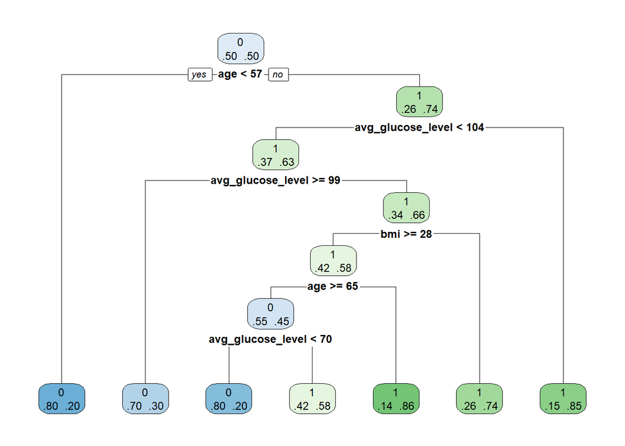

```r
cart <- rpart(stroke ~ ., data = train_DT, method = "class")
rpart.plot(cart, extra = 4)
```

# tính toán ma trận nhầm lẫn (confusion matrix) dựa trên dự đoán từ mô hình cây quyết định cart trên tập kiểm thử (test)

```r
confusionMatrix(predict(cart, test_DT, type = "class"), as.factor(test_DT$stroke), positive = "1", mode = "prec_recall")
```

```
## Confusion Matrix and Statistics
##
##           Reference
## Prediction  0  1
##          0 56 18
##          1 18 56
##
##                Accuracy : 0.7568
##                  95% CI : (0.6795, 0.8235)
##     No Information Rate : 0.5
##     P-Value [Acc > NIR] : 1.421e-10
##
##                   Kappa : 0.5135
##
##  Mcnemar's Test P-Value : 1
##
##               Precision : 0.7568
##                  Recall : 0.7568
##                      F1 : 0.7568
##              Prevalence : 0.5000
##          Detection Rate : 0.3784
##    Detection Prevalence : 0.5000
##       Balanced Accuracy : 0.7568
##
##        'Positive' Class : 1
##
```

===> Mô hình có độ chính xác là 75.68% tương đối tốt , nhưng cũng cần xem xét các chỉ số khác như precision và recall. Độ chính xác cân bằng và các chỉ số khác nhau không chênh lệch đáng kể, có thể cho thấy mô hình tương đối ổn định trên cả hai lớp. Giá trị Kappa là 0.5135, có thể được hiểu là mức đồng thuận tương đối tốt giữa dự đoán của mô hình và thực tế. Tóm lại, mô hình cây quyết định có hiệu suất tốt nhưng cũng cần được đánh giá kỹ lưỡng dựa trên các yếu tố như precision và recall để hiểu rõ hơn về khả năng dự đoán trên từng lớp.

# 6.THỰC NGHIỆM, KẾT QUẢ VÀ THẢO LUẬN

Dựa vào kết quả phân tích của 3 mô hình Hồi quy Logarit, Decision Tree và Random Forest, ta thấy :

[output not shown]

Nhận xét : Dùng mô hình Hồi quy Logarit là lựa chọn tốt nhất cho phân tích bệnh nhận bệnh đột quỵ. Thông qua các thông số như accuracy (độ chính xác), precision, recall và f1-score cao nhất trong các mô hình còn lại, và nó phù hợp với tập dữ liệu phân loại.

# 7. KẾT LUẬN (CONCLUSIONS)

- Các yếu tố ảnh hưởng đến tỷ lệ đột quỵ và tỷ lệ ảnh hưởng của chúng: . Bệnh nhân đột quỵ thường xuất hiện ở người lớn tuổi và người có chỉ số bmi cao.
- Thống kê độ tuổi thường mắc đột quỵ: . Người thuộc khoảng [68-1.58;68+1.58] có nguy cơ đột quỵ cao nhất.
- Xây dựng chương trình dự đoán nguy cơ đột quỵ: . Hồi quy Logarit . Random Forest . Decision Tree

==> Sử dụng mô hình Hồi quy Logarit là phù hợp với tập dữ liệu có biến phân loại và độ chính xác là 95%.

# 8. PHỤ LỤC (APPENDICES)

Tiêu chí đánh giá mô hình:

confusion matrix (ma trận nhầm lẫn): phân loại nhị phân positive negative positive TP FP negative FN TN

- Accuracy (độ chính xác): tính tỉ lệ giữa số mẫu dự đoán đúng và tổng số mẫu trong tập dữ liệu. Công thức: Accuracy = (TP + TN) / (TP + TN + FP + FN)
- Precision : là tỉ lệ số mẫu true positive trong số những mẫu được phân loại là positive (TP + FP). Thể hiện sự chuẩn xác của việc phát hiện các điểm Positive. Số này càng cao thì model nhận các điểm Positive càng chuẩn. Công thức : Precision = TP / (TP + FP)
- Recall : là tỉ lệ số mẫu true positive trong số những điểm thực sự là positive (TP+FN). Thể hiện khả năng phát hiện tất cả các postivie, tỷ lệ này càng cao thì cho thấy khả năng bỏ sót các điểm Positive là thấp. Công thức: Recall = TP / (TP + FN)
- F1 - score : F-1 score là trung bình điều hòa (harmonic mean) của precision và recall, có tầm quan trọng tương tự như với FNs và FPs. Là số dung hòa Recall và Precision giúp ta có căn cứ để lựa chọn model. F1 càng cao càng tốt. Công thức: F1 = 2 * (Precision * Recall) / (Precision + Recall)

==> Precision cao đồng nghĩa độ chính xác của các mẫu đúng là cao. Recall cao đồng nghĩa với việc bỏ sót các mẫu thực sự positive là thấp. Một mô hình phân lớp tốt là mô hình có cả Precision và Recall đều cao, tức càng gần một càng tốt. F-1 score càng cao tương ứng precision và recall càng cao, mô hình phân loại càng tốt.

# 9. ĐÓNG GÓP (CONTRIBUTIONS)

Ngoài 3 mô hình dùng để phân tích dữ liệu bệnh nhân đột quỵ, chúng ta có thể sử dụng mô hình k-nearest neighbors. Từ đó, việc sử dụng nhiều mô hình sẽ giúp có cách đánh giá tối ưu hơn và phương pháp của mô hình nào tốt hơn cho việc dự đoán kết quả.

# 10. KHAM KHẢO (REFERENCES)

[1] Logistic Regression - Bài toán cơ bản trong Machine Learning. https://viblo.asia/p/logistic-regression-bai-toan-co-ban-trong-machine-learning-924lJ4rzKPM

[2] Decision Tree in R Programming. https://www.geeksforgeeks.org/decision-tree-in-r-programming/

[3] Random Forest in R. https://www.r-bloggers.com/2021/04/random-forest-in-r/#google_vignette

[4] R Squared in R - How to Calculate R2 in R?. https://www.digitalocean.com/community/tutorials/r-squared-in-r-programming

[5] Trí tuệ nhân tạo: Các phương pháp đánh giá một mô hình phân loại. https://tapit.vn/cac-phuong-phap-danh-gia-mot-mo-hinh-phan-loai/?fbclid=IwAR1zQMzhFr3-DC3Q6DHOGHl0ancYKxC8YT5_IPeW8KT2PYMghCrfKZxYO78

# 11. PEER ASSSESSMENT

Nhận xét: Các nội dung nhóm đặt ra ở phần giới thiệu, hầu như trả lời được và vận dụng 3 mô hình cho việc phân tích từ đó đánh giá được mô hình nào sử dụng hiệu quả cho việc phân tích dữ liệu bệnh nhân bị đột quỵ.

### BẢNG PHÂN CHIA CÔNG VIỆC:

| Họ tên | MSSV | Công việc | Hoàn thành |
| --- | --- | --- | --- |
| Phan Khải Huyền | 21133048 | Triển khai mô hình Hồi quy Logarit + powerpoint | 100% |
| Nguyễn Quang Nhất Linh | 21133050 | Triển khai mô hình Decision Tree + tổng hợp nội dung source | 100% |
| Nguyễn Thị Thùy Linh | 21133051 | Trực quan hóa dữ liệu + EDA + tổng hợp nội dung source | 100% |
| Nguyễn Tấn Sương | 21133078 | Triển khai mô hình Random Forest + powerpoint | 100% |